# Plotting Systems (Swirl)

Mr. Sachin B.

### 1. Base Plotting System

- The first plotting system is the Base Plotting System which comes with R.
- It’s the oldest system which uses a simple “Artist’s palette” model. - What this means is that you start with a blank canvas and build your plot up from there, step by step.
- Usually you start with a `plot()` function (or something similar), then you use annotation functions to add to or modify your plot.
- R provides many annotating functions such as `text`, `lines`, `points`, and `axis`.
  - R provides documentation for each of these.
  - They all add to an already existing plot.
- The base system is very intuitive and easy to use when you’re starting to do exploratory graphing and looking for a research direction.
- You can’t go backwards, though, say, if you need to readjust margins or fix a misspelled a caption.
- A finished plot will be a series of R commands, so it’s difficult to translate a finished plot into a different system.

```r
# to see what the data looks like.
head(cars)
```

```
##   speed dist
## 1     4    2
## 2     4   10
## 3     7    4
## 4     7   22
## 5     8   16
## 6     9   10
```

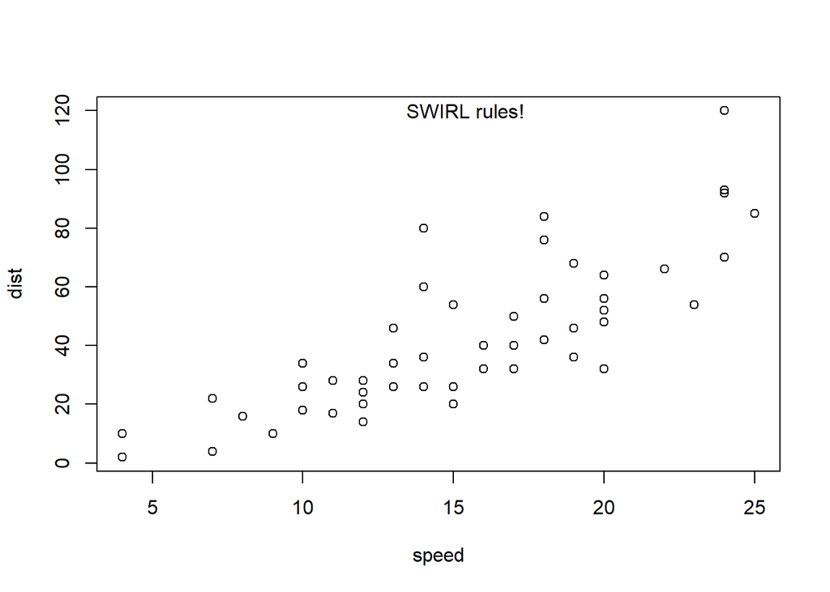

```r
#calling plot function
with(cars,plot(speed,dist))

# to add text to  the plot.
text(mean(cars$speed),max(cars$dist),"SWIRL rules!")
```

### 2. Lattice System

- The second plotting system, the Lattice System which comes in the package of the same name.
- Unlike the Base System, lattice plots are created with a single function call such as `xyplot` or `bwplot`.
- Margins and spacing are set automatically because the entire plot is specified at once.
- The lattice system is most useful for conditioning types of plots which display how y changes with x across levels of z.
  - The variable z might be a categorical variable of your data.
- This system is also good for putting many plots on a screen at once.  
  The lattice system has several disadvantages.
1. First, it is sometimes awkward to specify an entire plot in a single function call. Annotating a plot may not be especially intuitive.
2. Second, using panel functions and subscripts is somewhat difficult and requires preparation.
3. Finally, you cannot “add” to the plot once it is created as you can with the base system.

```r
state = read.csv("state.csv")
library(lattice)

# to see what the data looks like.
head(state)
```

```
##            X Population Income Illiteracy Life.Exp Murder HS.Grad Frost   Area
## 1    Alabama       3615   3624        2.1    69.05   15.1    41.3    20  50708
## 2     Alaska        365   6315        1.5    69.31   11.3    66.7   152 566432
## 3    Arizona       2212   4530        1.8    70.55    7.8    58.1    15 113417
## 4   Arkansas       2110   3378        1.9    70.66   10.1    39.9    65  51945
## 5 California      21198   5114        1.1    71.71   10.3    62.6    20 156361
## 6   Colorado       2541   4884        0.7    72.06    6.8    63.9   166 103766
##   region
## 1  South
## 2   West
## 3   West
## 4  South
## 5   West
## 6   West
```

```r
# to see how many categories there are and how many states are in each.
table(state$region)
```

```
##
## North Central     Northeast         South          West
##            12             9            16            13
```

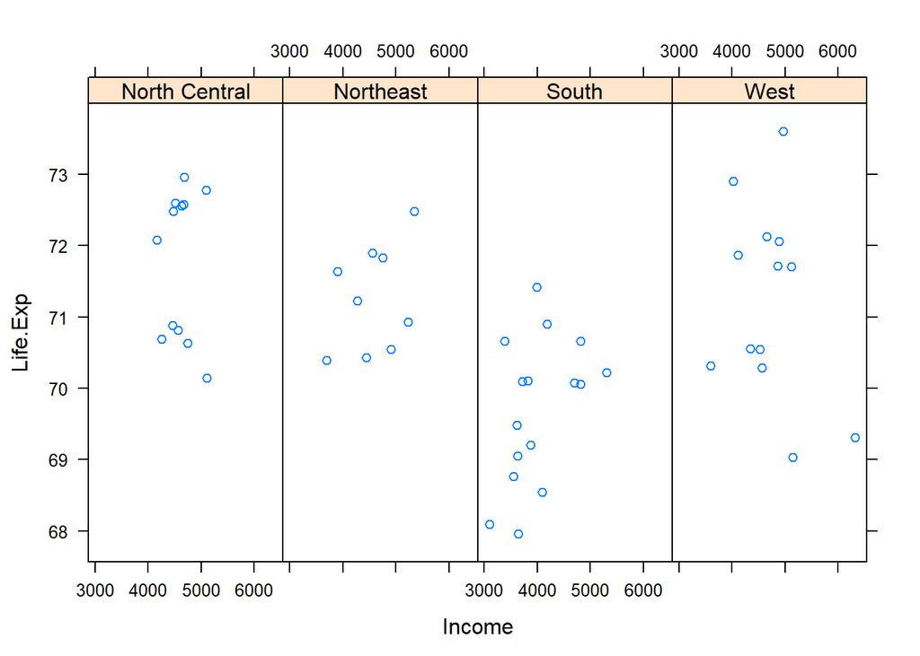

```r
# lattice command xyplot to see how life expectancy varies with income in each of the four regions.
xyplot(Life.Exp ~ Income | region, data = state, layout = c(4,1))
```

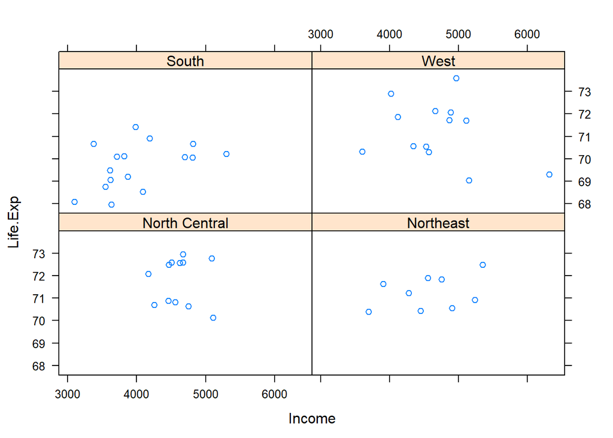

```r
# Just for fun rerun the xyplot and this time set layout to the vector c(2,2)
xyplot(Life.Exp ~ Income | region, data = state, layout = c(2,2)) # No need for you to worry about margins or labels. The package took care of all that for you.
```